# Chapter 3a - Pathway analysis (COPD)

Where in the pathway do inequalities in planned hospital care emerge?

Jake Parsons, The Strategy Unit

April 2021

### 1 Introduction

This chapter describes the relative scale of inequality within the COPD pathway. The analysis illustates relative and absolute differences in access to support and treatment along the care pathwway for COPD for patients in different socio economic groups.

### 2 Set-up and preparatory analysis

#### 2.1 Set-up

##### 2.1.1 Load required R packages

Set working directory.

Packages: tidyverse, scales, reshape, dplyr, purrr, tidyr, broom

```r
knitr::opts_chunk$set(
    echo = TRUE,
    message = FALSE,
    warning = FALSE
)


#setwd("Z:/Strategic Analytics/Projects 2020/753 Ineq planned Care/pathwaysAnalysis/R/r markdown/R Markdown #datafiles")

library(readxl)
library(tidyverse)
library(reshape)
library(dplyr)
library(purrr)
library(tidyr)
library(broom)
```

##### 2.1.2 Read in standard data sets

The first file contains counts of patients at each GP practice in England by the LSOA (and MSOA) in which they live https://digital.nhs.uk/data-and-information/publications/statistical/patients-registered-at-a-gp-practice/january-2020

The second file contains Index of multiple deprivation scores for LSOAs in england

https://assets.publishing.service.gov.uk/government/uploads/system/uploads/attachment_data/file/845345/File_7_-_All_IoD2019_Scores__Ranks__Deciles_and_Population_Denominators_3.csv

The third file contains a lookup table of practice code to CCG/STP/NHS region https://files.digital.nhs.uk/3A/ECBAEE/gp-reg-pat-prac-map_v2.csv

```r
 GPpatients_by_LSOA <- read_excel("patients by LSOA to GP.xlsx")

IMD2019 <- read_excel("IMD2019.xlsx")

practice_to_CCGSTP_lookup <- read_excel("gp-reg-pat-prac-map.xlsx")
```

##### 2.1.3 Read in activity and prevalence datasets

This file contains GP practice level counts of activity for each of the activity types included within this condition pathway. QOF data was downloaded from NHS digital website. Prescribing data was extracted from https://openprescribing.net/ OpenPrescribing.net, EBM DataLab, University of Oxford, 2021. ERS referral data was created from ERS extracts held by M&LCSU using Transact SQL Inpatient and outpatient activity data was created from record-level pseudonymised extracts from Hospital Episode Statistics, supplied by NHS Digital (DARS-NIC-05206-L1V6D-v4.6), using Transact SQL.  
Detailsof extraction criteria and TSQL scripts can be provided on request.

GP practice level estimates of the number of people with COPD is taken from the PHE fingertips tool https://fingertips.phe.org.uk/profile/prevalence. This data is a synthetic estimate details of the methodology used to derive these estimates are also avaialble on from the Fingertips website.

```r
Activity_data <-readRDS("copd_activity_data2.rds", refhook = NULL)
```

#### 2.2 Wrangle data

##### 2.2.1 Calculate deprivation deciles for GP practices in England

A weighted deprivation score is calculated for each GP practice based on the deprivation scores of their registrants’ LSOAs. GP practices are assigned to a decile based on their weighted deprivation score.

NHS organisational data (STP,CCG etc) is appended to each practice

```r
#appends LSOA IMD score to GPpatients_by_LSOA
GPpatients_by_LSOA3<- GPpatients_by_LSOA%>% left_join(select(IMD2019,`LSOA code (2011)`,`Index of Multiple Deprivation (IMD) Score`), by = c("LSOA_CODE" = "LSOA code (2011)"))

#creates new field of LSOA IMDscore multiplied by the number of patients from that LSOA
GPpatients_by_LSOA3<-GPpatients_by_LSOA3%>%
  mutate(scoretimespopLSOA = `Index of Multiple Deprivation (IMD) Score`*`Number of Patients`)

#groups data by Practice and sums number of patients and IMD score

working_data<-GPpatients_by_LSOA3%>%filter(!is.na(scoretimespopLSOA))%>%
  group_by (`PRACTICE_CODE`)%>%
  summarise(totalIMD = sum(`scoretimespopLSOA`),Patients = sum(`Number of Patients`)) %>%
  arrange()%>%

 #then calculates the average IMD (total IMD score/total Patients)

  mutate(averageIMD = `totalIMD`/`Patients`)%>%
#then calculates IMDDecile
  mutate(GP_IMDquantile = ntile(-`averageIMD`, 10))%>%
#adds in organisational data
  left_join(select(practice_to_CCGSTP_lookup,`CCG_CODE`,`CCG_NAME`,`STP_CODE`,`STP_NAME`,`COMM_REGION_NAME`,`PRACTICE_CODE`), by = c("PRACTICE_CODE" = "PRACTICE_CODE"))
```

##### 2.2.2 Append prevalence data and activity data to GP practice data

```r
  working_data<- working_data%>% left_join(select(Activity_data,1:12),by = c("PRACTICE_CODE" = "PRACTICE_CODE"))
```

##### 2.2.3 Wrangle data for Midlands Region output

Calculate activity to need ratios by deprivation centile

```r
 #Wrangle data for charts

  #Practices where prevalance data was not available are removed from the analysis. Where activity data at practice level was N/A zero activity of that type was assumed. NOTE this may not always be true but a review of the datasets suggested that this assumption was reasonable in most cases.

  Activity_by_type_decile_stg1<-working_data%>%
  filter(COMM_REGION_NAME == "MIDLANDS")%>%
  filter(COPD_prevalence_number != "NA")%>%
   mutate(QOF_total = replace_na(QOF_total, 0))%>%
  mutate(QOF_review_total = replace_na(QOF_review_total, 0))%>%
  mutate(QOF_flujab_total = replace_na(QOF_flujab_total, 0))%>%
  mutate(QOF_pulm_total = replace_na(QOF_pulm_total, 0))%>%
  mutate(inhalers_total = replace_na(inhalers_total, 0))%>%
   mutate(steroid_inhalers_total = replace_na(steroid_inhalers_total, 0))%>%
  mutate(steroid_tablets_total = replace_na(steroid_tablets_total, 0))%>%
  mutate(COPD_prevalence_number = replace_na(COPD_prevalence_number, 0))%>%
  mutate(ERS_referrals_total = replace_na(ERS_referrals_total, 0))%>%
  mutate(first_OP_atts_total = replace_na(first_OP_atts_total, 0))%>%
  mutate(lung_vol_red_total = replace_na(lung_vol_red_total, 0))%>%
  #mutate(lung_transplant_total = replace_na(lung_transplant_total, 0))%>%
  group_by (`GP_IMDquantile`)%>%
  summarise(QOF_total = sum(`QOF_total`),
     QOF_review_total = sum(`QOF_review_total`),
     QOF_flujab_total = sum(`QOF_flujab_total`),
     QOF_pulm_total = sum(`QOF_pulm_total`),
      inhalers_total = sum(`inhalers_total`),
      steroid_inhalers_total = sum(`steroid_inhalers_total`),
     ERS_referrals_total = sum(`ERS_referrals_total`),
      first_OP_atts_total = sum(`first_OP_atts_total`),
     steroid_tablets_total = sum(`steroid_tablets_total`),
     lung_vol_red_total = sum(`lung_vol_red_total`),
     #lung_transplant_total = sum(`lung_transplant_total`),
     COPD_prevalence_number = sum(`COPD_prevalence_number`)) %>%
  arrange()


Activity_by_type_decile_stg2<-Activity_by_type_decile_stg1%>%
  mutate(inhalers_ratio = inhalers_total/COPD_prevalence_number*1000) %>%
mutate(steroid_inhalers_ratio = steroid_inhalers_total/COPD_prevalence_number) %>%
  mutate(QOF_review_total_ratio = QOF_review_total/COPD_prevalence_number*1000)%>%
  mutate(QOF_total_ratio = QOF_total/COPD_prevalence_number*1000)%>%
  mutate(QOF_flujab_total_ratio = QOF_flujab_total/COPD_prevalence_number*1000)%>%
  mutate(QOF_pulm_total_ratio = QOF_pulm_total/COPD_prevalence_number*1000)%>%
  mutate(steroid_tablets_total_ratio = steroid_tablets_total/COPD_prevalence_number*1000) %>%
  mutate(ERS_referrals_total_ratio = ERS_referrals_total/COPD_prevalence_number*1000) %>%
  mutate(first_OP_atts_total_ratio = first_OP_atts_total/COPD_prevalence_number*1000) %>%
mutate(lung_vol_red_total_ratio = lung_vol_red_total/COPD_prevalence_number*1000)
#%>%
#mutate(lung_transplant_total_ratio = lung_transplant_total/COPD_prevalence_number*1000)


Activity_by_type_decile_stg3 <-melt(as.data.frame(Activity_by_type_decile_stg2), id.vars = c("GP_IMDquantile"),
                                    measure.vars = c("QOF_total_ratio","QOF_review_total_ratio",
                                                     "QOF_flujab_total_ratio","inhalers_ratio",
                                                     "steroid_inhalers_ratio",

                                                     "ERS_referrals_total_ratio","QOF_pulm_total_ratio",
                                                     "first_OP_atts_total_ratio",

                                                     "steroid_tablets_total_ratio","lung_vol_red_total_ratio"))
```

##### 2.2.4 Calculates Slope and relative Indices of inequality (SII and RII) for Midlands region

This code is adapted from R code developed by The Scottish Public Health. Details fo the methods can be found at Observatoryhttps://www.scotpho.org.uk/comparative-health/measuring-inequalities/

```r
SIIdata <-melt(as.data.frame(Activity_by_type_decile_stg2), id.vars = c("GP_IMDquantile","COPD_prevalence_number"),
                                      measure.vars = c("QOF_total_ratio","QOF_review_total_ratio",
                                                       "QOF_flujab_total_ratio","QOF_pulm_total_ratio",
                                                       "inhalers_ratio","steroid_inhalers_ratio",
                                                       "steroid_tablets_total_ratio",
                                                       "ERS_referrals_total_ratio","first_OP_atts_total_ratio",
                                                       "lung_vol_red_total_ratio"))



test_data <- SIIdata %>%
  select(variable,value =`value`,`COPD_prevalence_number`) %>%
  mutate(activity =(`value`*`COPD_prevalence_number`/1000))


activity_by_type_total<- test_data %>%
  group_by (`variable`)%>%
  summarise(total_activity = sum(`activity`),Prevalence =  sum(`COPD_prevalence_number`)) %>%
  #summarise(Patients = sum(`Number of Patients`)) %>%
  #summarise(totalIMD = sum(`scoretimespopLSOA`)) %>%
  arrange()

test_data <-test_data %>%
  left_join(select(activity_by_type_total,`variable`,`total_activity`,`Prevalence`),by = c("variable" = "variable"))


  test_data$overall_value = (test_data$total_activity/test_data$Prevalence*1000)

  test_data$quintile = c(1:10)

test_data$population = SIIdata$COPD_prevalence_number

#test_data$area = variable
  # Create a colum with the values for the most deprived and for the
  # least deprived quintiles. This is used for the ranges and PAR
test_data <-test_data %>%
mutate(most_depr_value = case_when(quintile == 1 ~ value, TRUE ~ 0),
         least_depr_value = case_when(quintile == 10 ~ value, TRUE ~ 0)) %>%
  group_by(variable) %>%
  mutate(most_depr_value = max(most_depr_value),
         least_depr_value = max(least_depr_value)) %>%
  #These variables are used for SII, RII and PAR calculation
  mutate(total_pop = sum(population), # calculate the total population for each area (without SIMD).
         proportion_pop = population/total_pop) # proportion of the population in each SIMD out of the total population.

###############################################.
## Absolute and relative range ----
###############################################.
# The absolute and relative ranges look at the differences and ratio between
# the most and leats deprived quintiles
test_data <- test_data %>%
  mutate(abs_range = most_depr_value - least_depr_value,
         rel_range = most_depr_value / least_depr_value) %>% ungroup()

#View(test_data)

###############################################.
## Population attributable risk (PAR) ----
###############################################.
#Calculation PAR
#Formula here: https://pdfs.semanticscholar.org/14e0/c5ba25a4fdc87953771a91ec2f7214b2f00d.pdf
# https://fhop.ucsf.edu/sites/fhop.ucsf.edu/files/wysiwyg/pg_apxIIIB.pdf

test_data <- test_data %>%
  mutate(par_rr = (value/least_depr_value - 1) * proportion_pop,
         par = sum(par_rr)/(sum(par_rr) + 1) * 100) %>% select(-par_rr)

#View(test_data)

###############################################.
## Slope of index on inequality (SII) ----
###############################################.
# The calculations below are those of the linear SII, you will have to amend the
# model if you wanted to calculate the Poisson SII
# This code will produce the results of the model, including confidence intervals
sii_model <- test_data %>%  group_by(variable) %>%
  mutate(cumulative_pro = cumsum(proportion_pop),  # cumulative proportion population for each area
         relative_rank = case_when(
           quintile == 1 ~ 0.5*proportion_pop,
           quintile != 1 ~ lag(cumulative_pro) + 0.5*proportion_pop),
         sqr_proportion_pop = sqrt(proportion_pop), #square root of the proportion of the population in each SIMD
         relrank_sqr_proppop = relative_rank * sqr_proportion_pop,
         value_sqr_proppop = sqr_proportion_pop * value) %>% #value based on population weights
  nest() %>% #creating one column called data with all the variables not in the grouping
  # Calculating linear regression for all the groups, then formatting the results
  # and calculating the confidence intervals
  mutate(model = map(data, ~ lm(value_sqr_proppop ~ sqr_proportion_pop + relrank_sqr_proppop + 0, data = .)),
         #extracting sii from model, a bit fiddly but it works
         sii = -1 * as.numeric(map(map(model, "coefficients"), "relrank_sqr_proppop")),
         cis = map(model, confint_tidy)) %>% #calculating confidence intervals
  ungroup() %>% unnest(cis) %>% #Unnesting the CIs
  #selecting only even row numbers which are the ones that have the sii cis
  filter(row_number() %% 2 == 0) %>%
  mutate(lowci_sii = -1 * conf.high, #fixing interpretation
         upci_sii = -1 * conf.low) %>%
  select(-conf.low, -conf.high) #non-needed variables

View(sii_model)

#Merging sii results with main data set
test_data <- left_join(test_data, sii_model, by = "variable")

#View(test_data)

###############################################.
## Relative index on inequality (RII) ----
###############################################.
#This is the calculation of the linear RII which is based on the SII values,
#so that section needs to be run before this one.
test_data <- test_data %>% mutate(rii = sii / overall_value,
                                  lowci_rii = lowci_sii / overall_value,
                                  upci_rii = upci_sii / overall_value,
                                  #Transforming RII into %. This way is interpreted as "most deprived areas are
                                  # xx% above the average" For example: Cancer mortality rate is around 55% higher
                                  # in deprived areas relative to the mean rate in the population
                                  rii_int = rii * 0.5 *100,
                                  lowci_rii_int = lowci_rii * 0.5 *100,
                                  upci_rii_int = upci_rii * 0.5 *100)

#View(test_data)

SII_table_COPD<-test_data %>%
  group_by (`variable`)%>%
  summarise(SII = mean(-`sii`),UCI = mean(-`upci_sii`),LCI = mean(-`lowci_sii`),
            RII = mean(-`rii`),UCI_RII = mean(-`upci_rii`),LCI_RII = mean(-`lowci_rii`),
            RR=mean(-`rel_range` )) %>%
  #summarise(Patients = sum(`Number of Patients`)) %>%
  #summarise(totalIMD = sum(`scoretimespopLSOA`)) %>%
  arrange()

SII_table_COPD
```

```
## # A tibble: 10 x 8
##    variable             SII      UCI     LCI     RII UCI_RII LCI_RII     RR
##    <fct>              <dbl>    <dbl>   <dbl>   <dbl>   <dbl>   <dbl>  <dbl>
##  1 QOF_total_ratio -1.38e+2 -1.68e+2 -1.09e2 -0.171  -0.208  -0.135  -1.16
##  2 QOF_review_tot~ -1.00e+2 -1.24e+2 -7.67e1 -0.159  -0.196  -0.121  -1.16
##  3 QOF_flujab_tot~ -1.52e+1 -4.15e+1  1.11e1 -0.0243 -0.0663  0.0177 -0.992
##  4 QOF_pulm_total~ -3.94e+1 -6.09e+1 -1.79e1 -0.410  -0.633  -0.186  -1.44
##  5 inhalers_ratio  -6.06e+3 -8.86e+3 -3.26e3 -0.355  -0.519  -0.191  -1.40
##  6 steroid_inhale~ -3.04e-1 -2.43e+0  1.82e0 -0.0260 -0.207   0.156  -1.01
##  7 steroid_tablet~  1.81e+3  1.13e+3  2.49e3  0.352   0.220   0.484  -0.815
##  8 ERS_referrals_~ -3.08e+1 -4.99e+1 -1.17e1 -0.179  -0.290  -0.0680 -1.21
##  9 first_OP_atts_~ -4.29e+1 -1.95e+2  1.09e2 -0.0648 -0.294   0.164  -0.983
## 10 lung_vol_red_t~  1.54e+0  4.86e-1  2.59e0  0.223   0.0707  0.376  -0.821
```

```r
## END
```

##### 2.2.5 Wrangle data for STP outputs

Calculate activity to need ratios by STP and deprivation centiles

```r
  #charts by  STP and Activity type


  Activity_by_type_STP_decile_stg1<-working_data%>%
  filter(COMM_REGION_NAME == "MIDLANDS")%>%
  filter(COPD_prevalence_number != "NA")%>%

  mutate(QOF_total = replace_na(QOF_total, 0))%>%
  mutate(QOF_review_total = replace_na(QOF_review_total, 0))%>%
  mutate(QOF_flujab_total = replace_na(QOF_flujab_total, 0))%>%
  mutate(QOF_pulm_total = replace_na(QOF_pulm_total, 0))%>%
  mutate(inhalers_total = replace_na(inhalers_total, 0))%>%
  mutate(steroid_inhalers_total = replace_na(steroid_inhalers_total, 0))%>%
  mutate(steroid_tablets_total = replace_na(steroid_tablets_total, 0))%>%
  mutate(COPD_prevalence_number = replace_na(COPD_prevalence_number, 0))%>%
  mutate(ERS_referrals_total = replace_na(ERS_referrals_total, 0))%>%
  mutate(first_OP_atts_total = replace_na(first_OP_atts_total, 0))%>%
  mutate(lung_vol_red_total = replace_na(lung_vol_red_total, 0))%>%
  #mutate(lung_transplant_total = replace_na(lung_transplant_total, 0))%>%
  group_by (`GP_IMDquantile`,`STP_NAME`)%>%
  summarise(QOF_total = sum(`QOF_total`),
            QOF_review_total = sum(`QOF_review_total`),
            QOF_flujab_total = sum(`QOF_flujab_total`),
            QOF_pulm_total = sum(`QOF_pulm_total`),
            inhalers_total = sum(`inhalers_total`),
            steroid_inhalers_total = sum(`steroid_inhalers_total`),
            ERS_referrals_total = sum(`ERS_referrals_total`),
            first_OP_atts_total = sum(`first_OP_atts_total`),
            steroid_tablets_total = sum(`steroid_tablets_total`),
            lung_vol_red_total = sum(`lung_vol_red_total`),
           # lung_transplant_total = sum(`lung_transplant_total`),
            COPD_prevalence_number = sum(`COPD_prevalence_number`)) %>%
  arrange()


Activity_by_type_STP_decile_stg2<-Activity_by_type_STP_decile_stg1%>%
  mutate(inhalers_ratio = inhalers_total/COPD_prevalence_number*1000) %>%
  mutate(steroid_inhalers_ratio = steroid_inhalers_total/COPD_prevalence_number) %>%
  mutate(QOF_review_total_ratio = QOF_review_total/COPD_prevalence_number*1000)%>%
  mutate(QOF_total_ratio = QOF_total/COPD_prevalence_number*1000)%>%
  mutate(QOF_flujab_total_ratio = QOF_flujab_total/COPD_prevalence_number*1000)%>%
  mutate(QOF_pulm_total_ratio = QOF_pulm_total/COPD_prevalence_number*1000)%>%
  mutate(steroid_tablets_total_ratio = steroid_tablets_total/COPD_prevalence_number*1000) %>%
  mutate(ERS_referrals_total_ratio = ERS_referrals_total/COPD_prevalence_number*1000) %>%
  mutate(first_OP_atts_total_ratio = first_OP_atts_total/COPD_prevalence_number*1000) %>%
  mutate(lung_vol_red_total_ratio = lung_vol_red_total/COPD_prevalence_number*1000)
#%>%
 # mutate(lung_transplant_total_ratio = lung_transplant_total/COPD_prevalence_number*1000)


Activity_by_type_STP_decile_stg3 <-melt(as.data.frame(Activity_by_type_STP_decile_stg2), id.vars = c("GP_IMDquantile","STP_NAME"),
                                    measure.vars = c("QOF_total_ratio","QOF_review_total_ratio",
                                                     "QOF_flujab_total_ratio",
                                                     "inhalers_ratio","steroid_inhalers_ratio",

                                                     "ERS_referrals_total_ratio","QOF_pulm_total_ratio","first_OP_atts_total_ratio",
                                                    "steroid_tablets_total_ratio", "lung_vol_red_total_ratio"))
```

##### 2.2.6 Calculates Slope and relative Indices of inequaltiy (SII and RII) by STP

This code is adapted from R code developed by The Scottish Public Health. Details fo the methods can be found at Observatory https://www.scotpho.org.uk/comparative-health/measuring-inequalities/

```r
SIIdata <-melt(as.data.frame(Activity_by_type_STP_decile_stg2), id.vars = c("STP_NAME","GP_IMDquantile","COPD_prevalence_number"),
                                      measure.vars = c("QOF_total_ratio","QOF_review_total_ratio",
                                                       "QOF_flujab_total_ratio","QOF_pulm_total_ratio",
                                                       "inhalers_ratio","steroid_inhalers_ratio",
                                                       "steroid_tablets_total_ratio",
                                                       "ERS_referrals_total_ratio","first_OP_atts_total_ratio",
                                                       "lung_vol_red_total_ratio"))



test_data <- SIIdata %>%
  select(STP_NAME,GP_IMDquantile,variable,value =`value`,`COPD_prevalence_number`) %>%
  mutate(activity =(`value`*`COPD_prevalence_number`/1000))


activity_by_type_total<- test_data %>%
  group_by (`STP_NAME`,`variable`)%>%
  summarise(total_activity = sum(`activity`),Prevalence =  sum(`COPD_prevalence_number`)) %>%
  #summarise(Patients = sum(`Number of Patients`)) %>%
  #summarise(totalIMD = sum(`scoretimespopLSOA`)) %>%
  arrange()

test_data <-test_data %>%
  left_join(select(activity_by_type_total,`variable`,`total_activity`,`Prevalence`),by = c("variable" = "variable","STP_NAME" ="STP_NAME"))


  test_data$overall_value = (test_data$total_activity/test_data$Prevalence*1000)

  test_data$quintile = SIIdata$GP_IMDquantile

test_data$population = SIIdata$COPD_prevalence_number

#test_data$area = variable
  # Create a colum with the values for the most deprived and for the
  # least deprived quintiles. This is used for the ranges and PAR
test_data <-test_data %>%
mutate(most_depr_value = case_when(quintile == 1 ~ value, TRUE ~ 0),
         least_depr_value = case_when(quintile == 10 ~ value, TRUE ~ 0)) %>%
  group_by(STP_NAME,variable) %>%
  mutate(most_depr_value = max(most_depr_value),
         least_depr_value = max(least_depr_value)) %>%
  #These variables are used for SII, RII and PAR calculation
  mutate(total_pop = sum(population), # calculate the total population for each area (without SIMD).
         proportion_pop = population/total_pop) # proportion of the population in each SIMD out of the total population.

###############################################.
## Absolute and relative range ----
###############################################.
# The absolute and relative ranges look at the differences and ratio between
# the most and leats deprived quintiles
test_data <- test_data %>%
  mutate(abs_range = most_depr_value - least_depr_value,
         rel_range = most_depr_value / least_depr_value) %>% ungroup()

#View(test_data)

###############################################.
## Population attributable risk (PAR) ----
###############################################.
#Calculation PAR
#Formula here: https://pdfs.semanticscholar.org/14e0/c5ba25a4fdc87953771a91ec2f7214b2f00d.pdf
# https://fhop.ucsf.edu/sites/fhop.ucsf.edu/files/wysiwyg/pg_apxIIIB.pdf

test_data <- test_data %>%
  mutate(par_rr = (value/least_depr_value - 1) * proportion_pop,
         par = sum(par_rr)/(sum(par_rr) + 1) * 100) %>% select(-par_rr)

#View(test_data)

###############################################.
## Slope of index on inequality (SII) ----
###############################################.
# The calculations below are those of the linear SII, you will have to amend the
# model if you wanted to calculate the Poisson SII
# This code will produce the results of the model, including confidence intervals
sii_model <- test_data %>%  group_by(STP_NAME,variable) %>%
  mutate(cumulative_pro = cumsum(proportion_pop),  # cumulative proportion population for each area
         relative_rank = case_when(
           quintile == 1 ~ 0.5*proportion_pop,
           quintile != 1 ~ lag(cumulative_pro) + 0.5*proportion_pop),
         sqr_proportion_pop = sqrt(proportion_pop), #square root of the proportion of the population in each SIMD
         relrank_sqr_proppop = relative_rank * sqr_proportion_pop,
         value_sqr_proppop = sqr_proportion_pop * value) %>% #value based on population weights
  nest() %>% #creating one column called data with all the variables not in the grouping
  # Calculating linear regression for all the groups, then formatting the results
  # and calculating the confidence intervals
  mutate(model = map(data, ~ lm(value_sqr_proppop ~ sqr_proportion_pop + relrank_sqr_proppop + 0, data = .)),
         #extracting sii from model, a bit fiddly but it works
         sii = -1 * as.numeric(map(map(model, "coefficients"), "relrank_sqr_proppop")),
         cis = map(model, confint_tidy)) %>% #calculating confidence intervals
  ungroup() %>% unnest(cis) %>% #Unnesting the CIs
  #selecting only even row numbers which are the ones that have the sii cis
  filter(row_number() %% 2 == 0) %>%
  mutate(lowci_sii = -1 * conf.high, #fixing interpretation
         upci_sii = -1 * conf.low) %>%
  select(-conf.low, -conf.high) #non-needed variables

#View(sii_model)

#Merging sii results with main data set
test_data <- left_join(test_data, sii_model, by = c("variable","STP_NAME"))

#View(test_data)

###############################################.
## Relative index on inequality (RII) ----
###############################################.
#This is the calculation of the linear RII which is based on the SII values,
#so that section needs to be run before this one.
test_data <- test_data %>% mutate(rii = sii / overall_value,
                                  lowci_rii = lowci_sii / overall_value,
                                  upci_rii = upci_sii / overall_value,
                                  #Transforming RII into %. This way is interpreted as "most deprived areas are
                                  # xx% above the average" For example: Cancer mortality rate is around 55% higher
                                  # in deprived areas relative to the mean rate in the population
                                  rii_int = rii * 0.5 *100,
                                  lowci_rii_int = lowci_rii * 0.5 *100,
                                  upci_rii_int = upci_rii * 0.5 *100)

#View(test_data)

SII_table_COPD_STP<-test_data %>%
  group_by (`STP_NAME`,`variable`)%>%
  summarise(SII = mean(-`sii`),UCI = mean(-`upci_sii`),LCI = mean(-`lowci_sii`),
            RII = mean(-`rii`),UCI_RII = mean(-`upci_rii`),LCI_RII = mean(-`lowci_rii`),
            RR=mean(-`rel_range` )) %>%
  #summarise(Patients = sum(`Number of Patients`)) %>%
  #summarise(totalIMD = sum(`scoretimespopLSOA`)) %>%
  arrange()


## END
```

### 3.0 Outputs

#### 3.1 Midlands Region chart

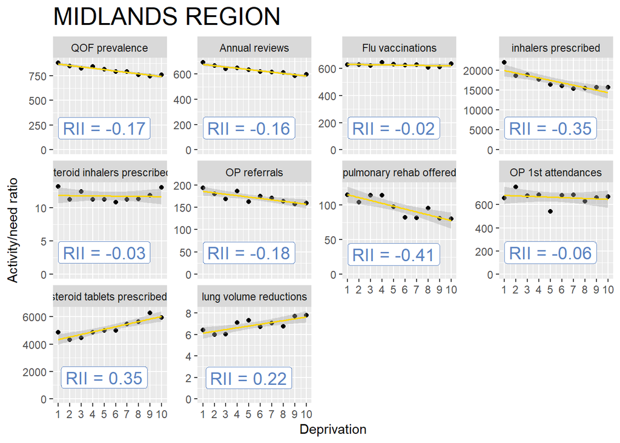

```r
  Activity_by_type_decile_stg4<-Activity_by_type_decile_stg3 %>%
  left_join(select(SII_table_COPD,`variable`,`SII`,RII ), by = c("variable" = "variable")) %>%
  mutate(value = round(value,digits = 2)) %>%
  mutate(RII = round(RII,digits = 2)) %>%
  mutate(SII = round(SII,digits = 0))





COPD_region_chart<-Activity_by_type_decile_stg4 %>%
  ggplot( aes(GP_IMDquantile,value))+

  #geom_line(stat="identity")+
  geom_point(stat="identity")+
  ylim(0, NA)+
  stat_smooth(method=lm,fill="gray65", colour="gold1", size=0.7)+
  #facet_wrap(STP_NAME ~ variable, scales="free")
  #geom_label(x=5, y=0.2*max(Activity_by_type_decile_stg3$value), label="Scatter plot")+
  facet_wrap(variable ~ ., scales="free_y",labeller = labeller(variable =
                                                                 c("QOF_total_ratio" = "QOF prevalence",
                                                                   "QOF_review_total_ratio" = "Annual reviews",
                                                                    "QOF_flujab_total_ratio" = "Flu vaccinations",
                                                                    "QOF_pulm_total_ratio"= "pulmonary rehab offered",
                                                                    "inhalers_ratio"= "inhalers prescribed",
                                                                    "steroid_inhalers_ratio"= "steroid inhalers prescribed",
                                                                    "steroid_tablets_total_ratio"= "steroid tablets prescribed ",
                                                                   "ERS_referrals_total_ratio"= "OP referrals",
                                                                   "first_OP_atts_total_ratio"= "OP 1st attendances",
                                                                    "lung_vol_red_total_ratio"= "lung volume reductions")))+
  scale_x_continuous(breaks=seq(0, 10, 1))+
  ggtitle("MIDLANDS REGION")+
  theme(plot.title = element_text( size = 20))+
  geom_label(data = Activity_by_type_decile_stg4 %>%
               group_by(variable) %>%
               summarise(across(RII, first),
                         across(value, max) * .25,
                         x = 5),
             aes(x, value, label = paste("RII =", RII)),
             size = 5, colour = "#5881c1")+
  labs( x="Deprivation", y="Activity/need ratio")

COPD_region_chart
```

#### 3.2 Midlands Region summary chart

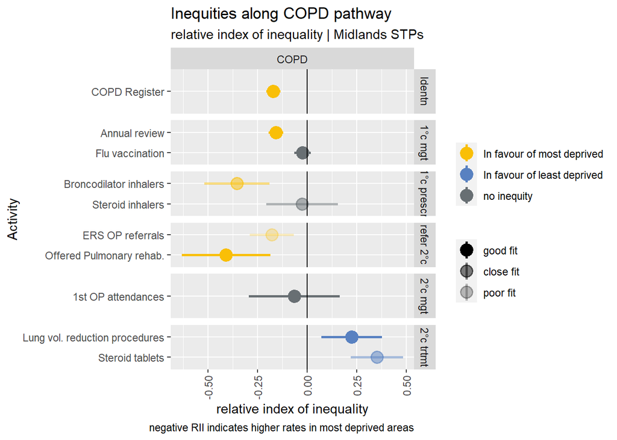

```r
#reads in RII data and assumptions about condition to measure fit
RII_data <- read_excel('RII data all.xlsx')

chartDf <- RII_data %>%
  mutate(pathwayLevel = case_when(Activity == 'HF register' ~ 'Identn',
                                  Activity == 'Diag confirmed by ECG' ~ '1Â°c mgt',
                                  Activity == 'ACEi' ~ '1Â°c prescr',
                                  Activity == 'ARBs' ~ '1Â°c prescr',
                                  Activity == 'Betablockers' ~ '1Â°c prescr',
                                  Activity == 'Sacubitril' ~ '1Â°c prescr',
                                  Activity == 'Digoxin' ~ '1Â°c prescr',
                                  Activity == 'Pacemakers' ~ '2Â°c trtmt',
                                  Activity == 'Valve repair' ~ '2Â°c trtmt',
                                  Activity == 'COPD Register' ~ 'Identn',
                                  Activity == 'Annual review' ~ '1Â°c mgt',
                                  Activity == 'Flu vaccination' ~ '1Â°c mgt',
                                  Activity == 'Offered Pulmonary rehab.' ~ 'refer 2Â°c',
                                  Activity == 'Broncodilator inhalers' ~ '1Â°c prescr',
                                  Activity == 'Steroid inhalers' ~ '1Â°c prescr',
                                  Activity == 'Steroid tablets' ~ '2Â°c trtmt',
                                  Activity == 'ERS OP referrals' ~ 'refer 2Â°c',
                                  Activity == '1st OP attendances' ~ '2Â°c mgt',
                                  Activity == 'Lung vol. reduction procedures' ~ '2Â°c trtmt',
                                  Activity == 'Arthritis register' ~ 'Identn',
                                  Activity == 'F2F review' ~ '1Â°c mgt',
                                  Activity == 'Physio referrals' ~ 'refer 2Â°c',
                                  Activity == 'Orthopaedic OP referrals' ~ 'refer 2Â°c',
                                  Activity == '1st OP attendances' ~ '2Â°c mgt',
                                  Activity == '1st OP telephone attendances' ~ '2Â°c mgt',
                                  Activity == 'OP injections' ~ '2Â°c trtmt',
                                  Activity == 'Hip replacements' ~ '2Â°c trtmt',
                                  Activity == 'Hip replacement revisions' ~ '2Â°c trtmt',
                                  Activity == 'ERS OP referrals' ~ 'refer 2Â°c',
                                  Activity == '1st OP attendances' ~ '2Â°c mgt',
                                  Activity == 'IP procedures' ~ '2Â°c trtmt',
                                  Activity == 'OP procedures' ~ '2Â°c trtmt',
                                  Activity == 'Total procedures' ~ '2Â°c trtmt')) %>%
  bind_rows(data.frame(Condition = c('Heart Failure', 'Heart Failure', 'Hip Arthritis',
                                     'Cataracts', 'Cataracts', 'Cataracts'),
                       Activity = c('', '', '', '', '', ''),
                       RII = c(NA_real_, NA_real_, NA_real_, NA_real_, NA_real_, NA_real_),
                       RII_UCI = c(NA_real_, NA_real_, NA_real_, NA_real_, NA_real_, NA_real_),
                       RII_LCI = c(NA_real_, NA_real_, NA_real_, NA_real_, NA_real_, NA_real_),
                       needtoactivity_match_quality = c(3, 3, 3, 3, 3, 3),
                       Activity2 = c('', '', '', '', '', ''),
                       `...8` = c('', '', '', '', '', ''),
                       pathwayLevel = c('refer 2Â°c', '2Â°c mgt', '1Â°c prescr',
                                        'Identn', '1Â°c mgt', '1Â°c prescr'))) %>%
  mutate(pathwayLevel = factor(pathwayLevel, levels = c('Identn', '1Â°c mgt', '1Â°c prescr',
                                                        'refer 2Â°c', '2Â°c mgt', '2Â°c trtmt'))) %>%
  mutate(fitLabel = case_when(needtoactivity_match_quality == 1 ~ 'good fit',
                              needtoactivity_match_quality == 2 ~ 'close fit',
                              needtoactivity_match_quality == 3 ~ 'poor fit')) %>%
  mutate(fitLabel = factor(fitLabel, levels = c('good fit', 'close fit', 'poor fit'))) %>%
  mutate(Condition = factor(Condition, levels = c('COPD', 'Heart Failure',
                            'Hip Arthritis', 'Cataracts'))) %>%
  mutate(slopeBinary = case_when(RII_UCI > 0 ~ 'In favour of least deprived',
                                 RII_LCI < 0 ~ 'In favour of most deprived',
                                 TRUE ~ 'no inequity')) %>%
  # mutate(slopeBinary = case_when(RII > 0 ~ 'towards most deprived',
  #                                RII < 0 ~ 'towards least deprived')) %>%
  mutate(slopeBinary = factor(slopeBinary, levels = c('In favour of most deprived','In favour of least deprived', 'no inequity'))) %>%

  filter(Activity2 != 'E Total procedures')


copdChart <- chartDf %>%
  filter(Condition == 'COPD') %>%
  mutate(Condition = droplevels(Condition)) %>%
  ggplot() +
  geom_pointrange(aes(y=Activity, x=RII,
                      xmin = RII_LCI, xmax = RII_UCI,
                      alpha = fitLabel,
                      colour = slopeBinary),
                  size =1)+
  geom_vline(aes(xintercept = 0)) +
  scale_y_discrete(limits = rev) +
  scale_alpha_manual(values = c(1, 0.5, 0.25)) +
  scale_colour_manual(values = c('#f9bf07', '#5881c1', '#686f73')) +
  facet_grid(cols = vars(Condition),
             rows = vars(pathwayLevel),
             scales='free_y',
             drop = FALSE) +
  xlab('relative index of inequality') + ylab('Activity') +
  labs(caption = ' negative RII indicates higher rates in most deprived areas',
       title = 'Inequities along COPD pathway',
       subtitle = 'relative index of inequality | Midlands STPs') +
  theme(axis.text.x = element_text(angle = 90, vjust = 0.5, hjust=1),
        legend.title = element_blank())+
  guides(colour = guide_legend(order = 1), alpha = guide_legend(order = 2))

copdChart
```

#### 3.3 STP charts

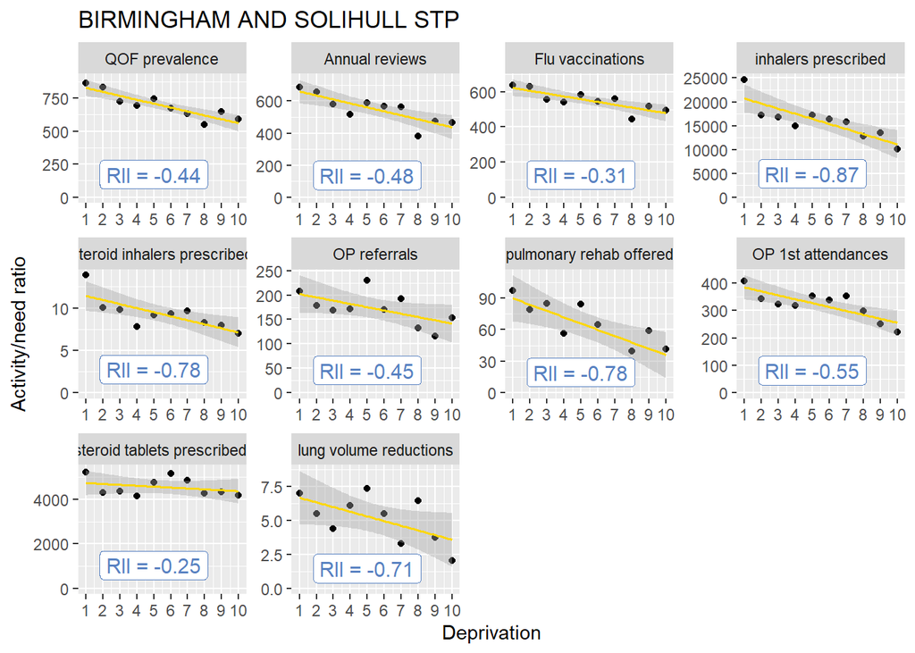

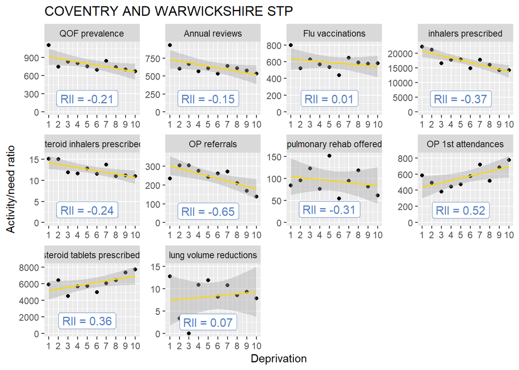

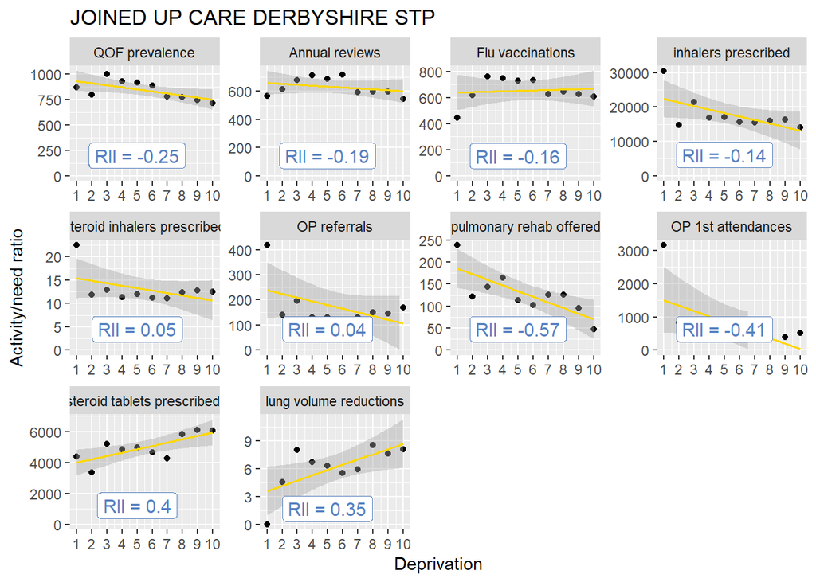

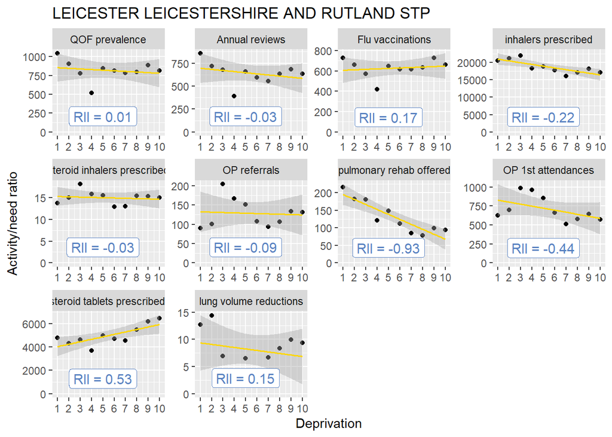

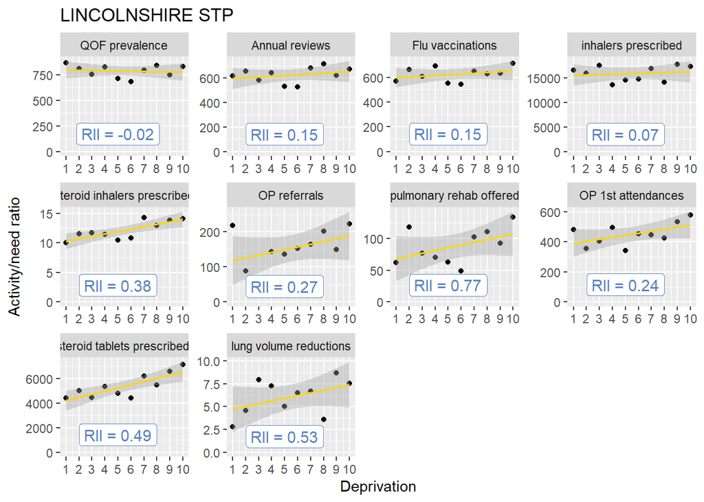

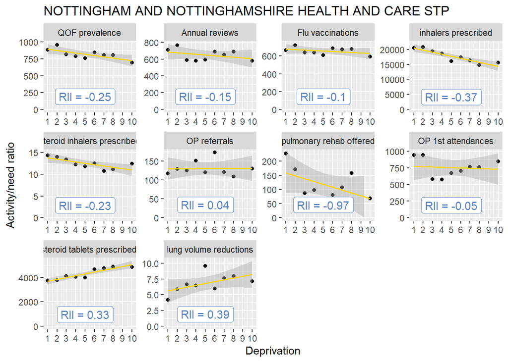

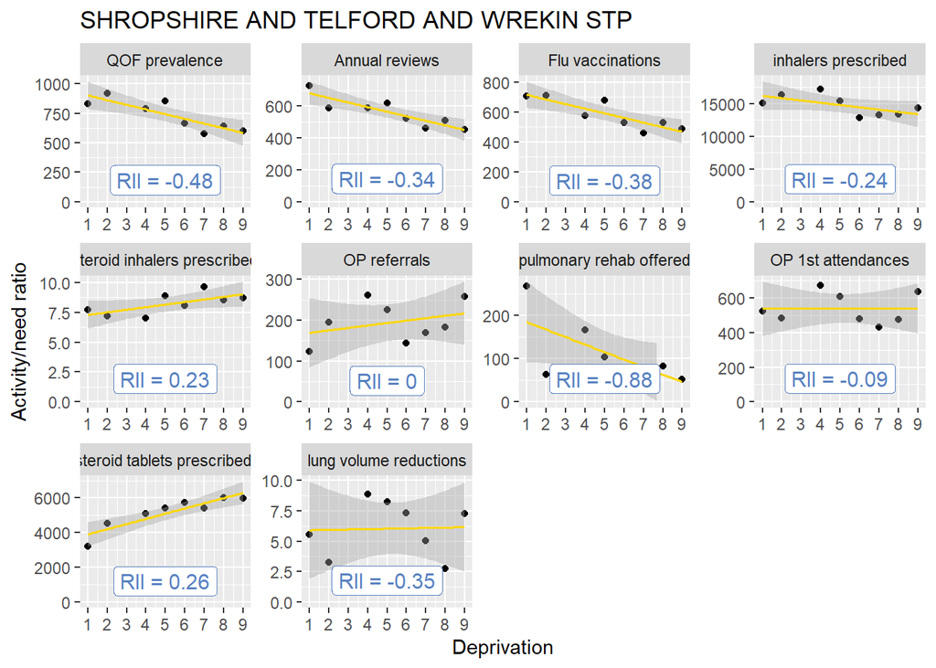

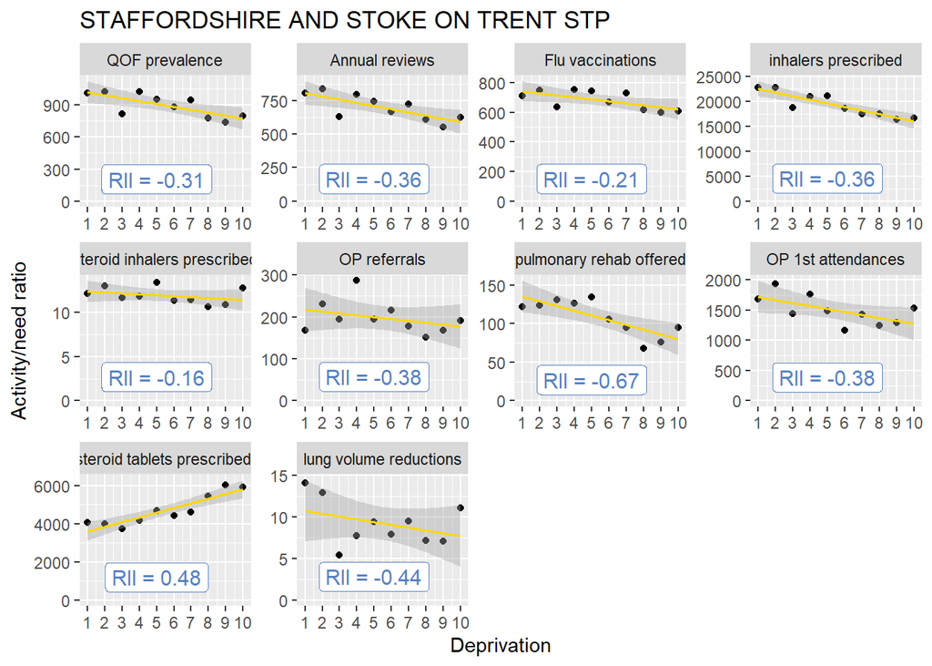

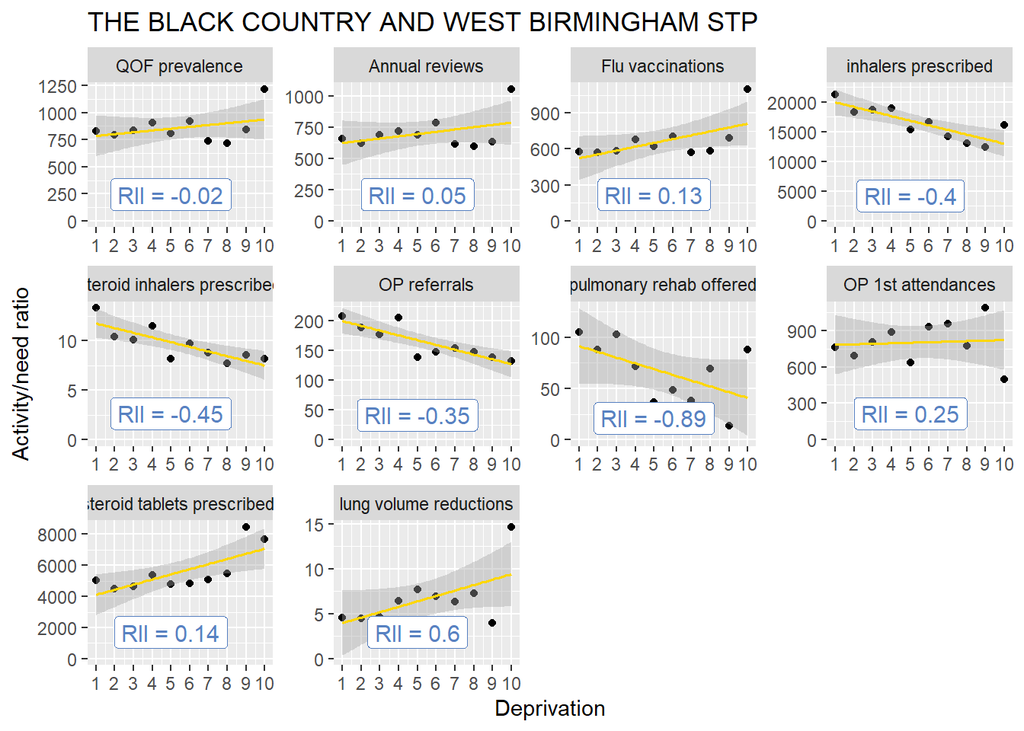

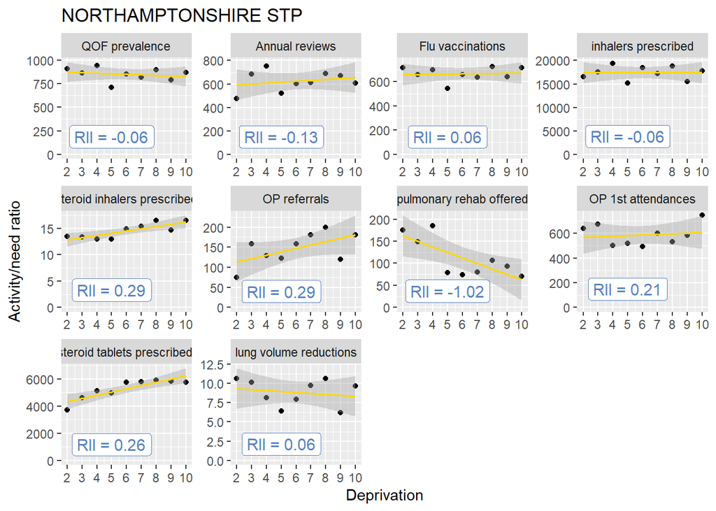

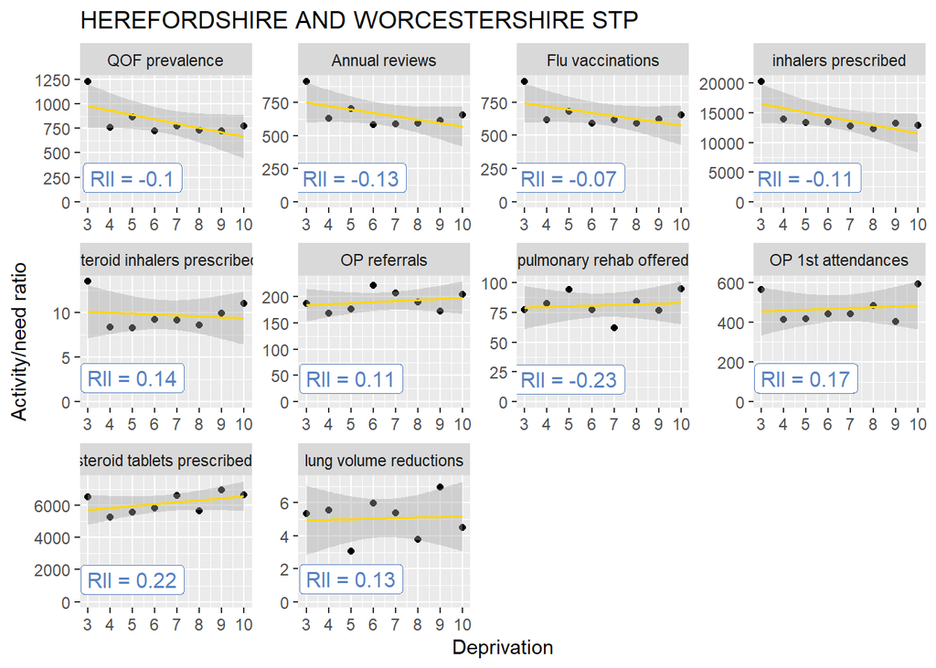

```r
Activity_by_type_STP_decile_stg4<-Activity_by_type_STP_decile_stg3 %>%
    filter(variable != "lung_transplant_total_ratio") %>%
  left_join(select(SII_table_COPD_STP,`variable`,`SII`,RII ), by = c("STP_NAME"="STP_NAME","variable" = "variable")) %>%
  mutate(value = round(value,digits = 2)) %>%
  mutate(RII = round(RII,digits = 2)) %>%
  mutate(SII = round(SII,digits = 0))


vars =unique(Activity_by_type_STP_decile_stg4$STP_NAME)
plots = list()
for(variable_ in vars )

{
  plots[[variable_]] =  ggplot( Activity_by_type_STP_decile_stg4 %>% filter(STP_NAME == variable_),
                                aes(GP_IMDquantile,value))+

    geom_point(stat="identity")+
    ylim(0, NA)+
    labs(title = variable_, x="Deprivation", y="Activity/need ratio")+


    scale_x_continuous(breaks=seq(0, 10, 1))+
    stat_smooth(method=lm,fill="gray65", colour="gold1", size=0.7 )+
    facet_wrap(variable ~ ., scales="free",labeller = labeller(variable =
                                                                 c("QOF_total_ratio" = "QOF prevalence",
                                                                   "QOF_review_total_ratio" = "Annual reviews",
                                                                   "QOF_flujab_total_ratio" = "Flu vaccinations",
                                                                   "QOF_pulm_total_ratio"= "pulmonary rehab offered",
                                                                   "inhalers_ratio"= "inhalers prescribed",
                                                                   "steroid_inhalers_ratio"= "steroid inhalers prescribed",
                                                                   "steroid_tablets_total_ratio"= "steroid tablets prescribed ",
                                                                   "ERS_referrals_total_ratio"= "OP referrals",
                                                                   "first_OP_atts_total_ratio"= "OP 1st attendances",
                                                                   "lung_vol_red_total_ratio"= "lung volume reductions"
                                                                   )))+
    geom_label(data = Activity_by_type_STP_decile_stg4%>% filter(STP_NAME == variable_) %>%
                 group_by(variable) %>%
                 summarise(across(RII, first),
                           across(value, max) * .2,
                           x = 5),
               aes(x, value, label = paste("RII =", RII)),
               size = 4, colour = "#5881c1")

  print(plots[[variable_]])
}
```